# STAT 3240 Project Proposal

Group 5

Last updated on 2023-12-07

```r
knitr::opts_chunk$set(echo = TRUE)


#specify the packages of interest
packages = c("ALSM", "mosaic", "car", "leaps", "tidyverse", "here")

#use this function to check if each package is on the local machine
#if a package is installed, it will be loaded
#if any are not, the missing package(s) will be installed and loaded
if (!require("pacman")) install.packages("pacman")
pacman::p_load(char=packages)
# Load all packages here:
library(readr)
library(dplyr)
library(ggplot2)
library(janitor)

# Set seed value of random number generator to get "replicable" random numbers.
# The choice of seed value of 76 was an arbitrary one on my part.
set.seed(76)
```

# Big-picture

## Research question

What is the relationship of Polio immunization coverage among 1-year-olds and infant deaths in the year 2000 on life expectancy across all continents in the year 2015?

## Description of data

The original source: https://www.kaggle.com/datasets/kumarajarshi/life-expectancy-who This data set was provided by the United Nations (UN) and the World Health Organization (WHO). These organizations provide valid data that can be used for data analysis related to health. Description: Our data set considers data from a time period of 2000 to 2015 for all continents. We will be looking into important variables such as Polio and Infant Deaths. The “Polio” variable represents: Polio (Pol3) immunization coverage among 1-year-olds as a percentage (%). The “Life Expectancy” variable represents Life Expectancy in years.

```r
group_5 <- read.csv("https://docs.google.com/spreadsheets/d/e/2PACX-1vTlV5daNBBEPs5gBHfUpdvk8SDndr1WuS0B388e24hQj44dfUF2zI9Q5CceuBgF6kNNfEDnxseL_SQM/pub?gid=1089656543&single=true&output=csv")
```

```r
group_5 <- group_5 %>%
  clean_names()
glimpse(group_5)
```

```
## Rows: 2,938
## Columns: 23
## $ continent                       <chr> "Asia", "Asia", "Asia", "Asia", "Asia"…
## $ country                         <chr> "Afghanistan", "Afghanistan", "Afghani…
## $ year                            <int> 2015, 2014, 2013, 2012, 2011, 2010, 20…
## $ status                          <chr> "Developing", "Developing", "Developin…
## $ life_expectancy                 <dbl> 65.0, 59.9, 59.9, 59.5, 59.2, 58.8, 58…
## $ adult_mortality                 <int> 263, 271, 268, 272, 275, 279, 281, 287…
## $ infant_deaths                   <int> 62, 64, 66, 69, 71, 74, 77, 80, 82, 84…
## $ alcohol                         <dbl> 0.01, 0.01, 0.01, 0.01, 0.01, 0.01, 0.…
## $ percentage_expenditure          <dbl> 71.279624, 73.523582, 73.219243, 78.18…
## $ hepatitis_b                     <int> 65, 62, 64, 67, 68, 66, 63, 64, 63, 64…
## $ measles                         <int> 1154, 492, 430, 2787, 3013, 1989, 2861…
## $ bmi                             <dbl> 19.1, 18.6, 18.1, 17.6, 17.2, 16.7, 16…
## $ under_five_deaths               <int> 83, 86, 89, 93, 97, 102, 106, 110, 113…
## $ polio                           <int> 6, 58, 62, 67, 68, 66, 63, 64, 63, 58,…
## $ total_expenditure               <dbl> 8.16, 8.18, 8.13, 8.52, 7.87, 9.20, 9.…
## $ diphtheria                      <int> 65, 62, 64, 67, 68, 66, 63, 64, 63, 58…
## $ hiv_aids                        <dbl> 0.1, 0.1, 0.1, 0.1, 0.1, 0.1, 0.1, 0.1…
## $ gdp                             <dbl> 584.25921, 612.69651, 631.74498, 669.9…
## $ population                      <dbl> 33736494, 327582, 31731688, 3696958, 2…
## $ thinness_1_19_years             <dbl> 17.2, 17.5, 17.7, 17.9, 18.2, 18.4, 18…
## $ thinness_5_9_years              <dbl> 17.3, 17.5, 17.7, 18.0, 18.2, 18.4, 18…
## $ income_composition_of_resources <dbl> 0.479, 0.476, 0.470, 0.463, 0.454, 0.4…
## $ schooling                       <dbl> 10.1, 10.0, 9.9, 9.8, 9.5, 9.2, 8.9, 8…
```

```r
group_2015 <- group_5 %>% filter(year==2015) %>% arrange(country)
group_5 <- group_5 %>%
  filter(year==2000) %>%
  arrange(country) %>%
  mutate(life_expectancy=group_2015$life_expectancy) %>%
  rename("life_expectancy_2015" = "life_expectancy") %>%
  select(!year)
```

```r
group_5 <- group_5 |> select(life_expectancy_2015, polio, continent, infant_deaths)
```

```r
group_5[is.na(group_5)] <- 0
colSums(is.na(group_5))
```

```
## life_expectancy_2015                polio            continent
##                    0                    0                    0
##        infant_deaths
##                    0
```

# Analysis and Results

```r
polio_model <- lm(life_expectancy_2015~polio+infant_deaths+continent,data=group_5)
msummary(polio_model)
```

```
##                         Estimate Std. Error t value Pr(>|t|)
## (Intercept)            59.216783   1.099027  53.881  < 2e-16 ***
## polio                   0.063890   0.014694   4.348 2.33e-05 ***
## infant_deaths          -0.003716   0.002573  -1.444     0.15
## continentAsia           8.567663   1.105286   7.752 7.12e-13 ***
## continentEurope        13.831806   1.152441  12.002  < 2e-16 ***
## continentNorth America 11.488277   1.300526   8.834 1.04e-15 ***
## continentOceania        8.686192   1.732857   5.013 1.31e-06 ***
## continentSouth America 10.959544   1.633474   6.709 2.61e-10 ***
##
## Residual standard error: 5.007 on 175 degrees of freedom
## Multiple R-squared:  0.6347, Adjusted R-squared:  0.6201
## F-statistic: 43.44 on 7 and 175 DF,  p-value: < 2.2e-16
```

1. Intercept (59.22): The estimated intercept is the expected value of life expectancy when infant deaths,polio is zero and the continent in consideration is Africa.
2. Polio (0.06389): We expect the average life expectancy to increase by 0.06389 years for every 1% increase in polio immunization in one year olds when there is no infant deaths and the continent is Africa.
3. Infant Deaths (-0.003716): We expect the average life expectancy to decrease by 0.003716 years when the number of infant deaths increase by one and there is no polio immunization and the continent is Africa.
4. ContinentAsia (8.57): The coefficient for “continentAsia” is 8.57. This means that when polio immunization and infant deaths are the same, average life expectancy in Asia is estimated to increase by 8.57 years compared to Africa.
5. ContinentEurope (13.83): The coefficient for “continentEurope” is 13.83. This means that when polio immunization and infant deaths are the same, average life expectancy in Europe is estimated to increase by 13.83 years compared to Africa.
6. ContinentNorth America (11.49): The coefficient for “continentNorth America” is 11.49. This means that when polio immunization and infant deaths are the same, average life expectancy in North America is estimated to increase by 11.49 years compared to Africa.
7. ContinentOceania (8.69): The coefficient for “continentOceania” is 8.69. This means that when polio immunization and infant deaths are the same, average life expectancy in Oceania is estimated to increase by 8.69 years compared to Africa.
8. ContinentSouth America (10.96): The coefficient for “continentSouthAmerica” is 10.96. This means that when polio immunization and infant deaths are the same, average life expectancy in South America is estimated to increase by 10.96 years compared to Africa.
9. P-values: The p-values associated with each coefficient test the null hypothesis that the true coefficient is zero. Smaller p-values (< 0.05) indicate that the variable is likely to be significant. In this case, “polio” and all “continents” variables have p-values less than 0.05, suggesting they are statistically significant.
10. Residual Standard Error (5.007): This is an estimate of the standard deviation of the residuals. It provides a measure of how well the model fits the data. Lower values indicate a better fit.
11. R-squared (0.6347): The R-squared value measures the proportion of variance in the dependent variable (life expectancy) explained by the model. In this case, around 63.47% of the variability in life expectancy is explained by the model. The adjusted R-squared penalises for the amount of predictor variables in our model which in this case is 62.01%
12. F-statistic (43.44): This tests the overall significance of the model. A high F-statistic (and low p-value) suggests that at least one predictor variable is related to the response variable. In this case, the model explains a significant amount of variation in life expectancy across continents.

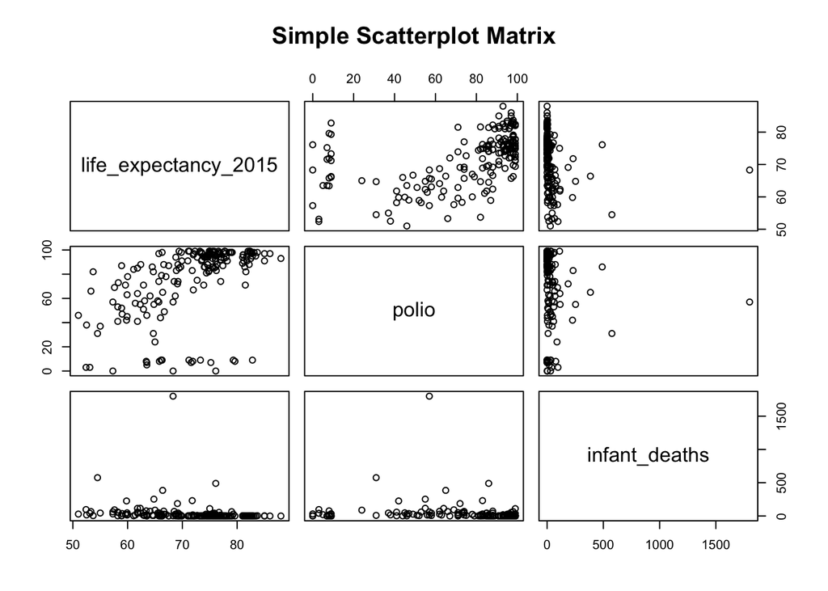

```r
pairs(~life_expectancy_2015 + polio + infant_deaths, data=group_5, main="Simple Scatterplot Matrix")
```

Simple Scatterplot Matrix: The plot shows that as polio immunization increases life expectancy also tends to increase. Additionally, there appears to be a negative correlation between infant deaths and polio as all the points are clustered to the left. The same can be said for life expectancy and infant deaths that there is a negative correlation.

To further check the correlation between the variables we used the Pearson Method. The correlation between Polio and Life expectancy is 0.513. The correlation between Infant Deaths and Life expectancy is -0.17. The correlation between Infant Deaths and polio is -0.1267

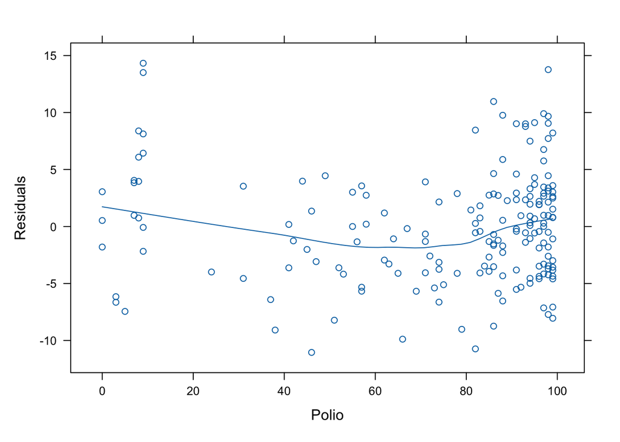

```r
xyplot(resid(polio_model)~group_5$polio, ylab="Residuals", xlab="Polio", type=c("p", "smooth"))
```

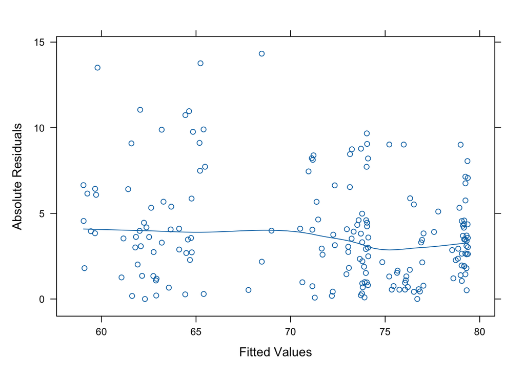

```r
xyplot(abs(resid(polio_model))~predict(polio_model), ylab="Absolute Residuals", xlab="Fitted Values", type=c("p", "smooth"))
```

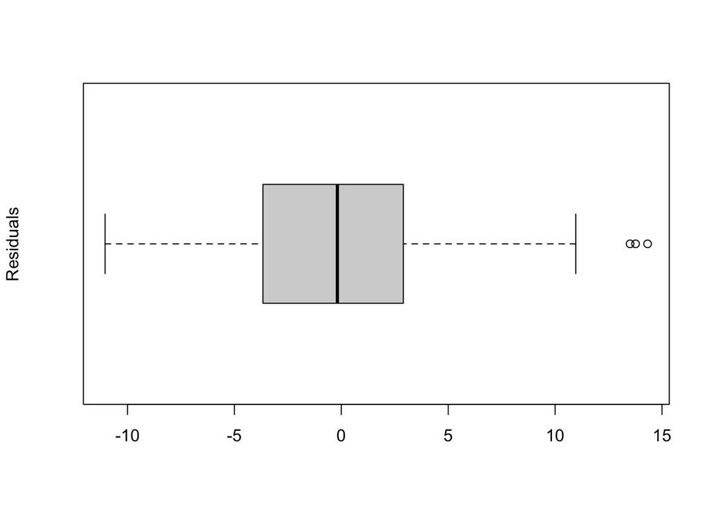

```r
boxplot(resid(polio_model), ylab="Residuals", horizontal=TRUE)
```

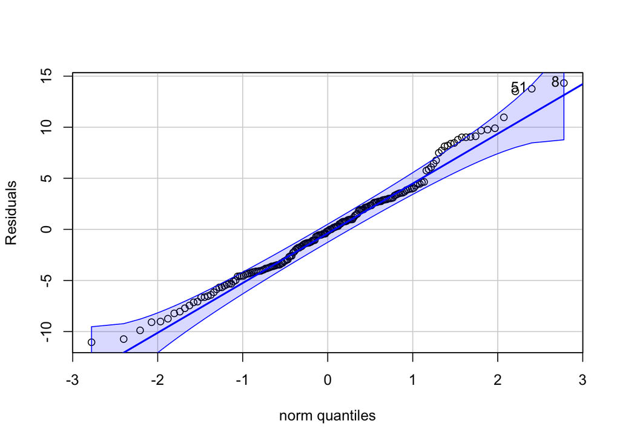

```
## [1]  8 51
```

```r
qqPlot(resid(polio_model), ylab="Residuals")
```

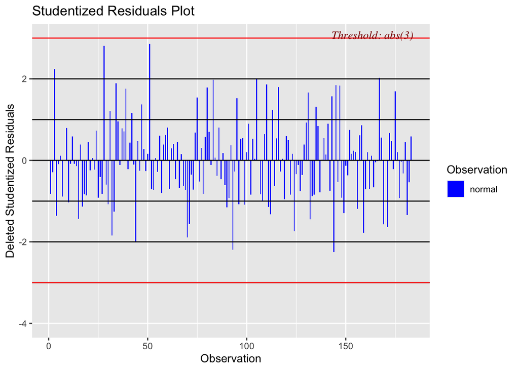

```r
olsrr::ols_plot_resid_stud(polio_model)
```

Interpreting Plots…